```python
# Foi necessário correr o seguinte no terminal:
# pip install git+https://github.com/qiskit-community/qiskit-textbook.git#subdirectory=qiskit-textbook-src

from matplotlib import pyplot as plt
import numpy as np

from qiskit import IBMQ, QuantumCircuit, Aer, QuantumRegister, ClassicalRegister, execute
from qiskit.visualization import plot_bloch_multivector, plot_histogram, plot_bloch_vector
import qiskit.tools.jupyter
from qiskit.quantum_info import Statevector

%matplotlib inline
%qiskit_version_table
```

Version Information

| Qiskit Software | Version |
| --- | --- |
| Qiskit | 0.21.0 |
| Terra | 0.15.2 |
| Aer | 0.6.1 |
| Ignis | 0.4.0 |
| Aqua | 0.7.5 |
| IBM Q Provider | 0.9.0 |
| System information |  |
| Python | 3.7.6 (default, Jan 8 2020, 20:23:39) [MSC v.1916 64 bit (AMD64)] |
| OS | Windows |
| CPUs | 4 |
| Memory (Gb) | 7.945156097412109 |
| Wed Aug 03 14:16:09 2022 Hora de Verão de GMT |  |

# Primeiros Circuitos Quânticos

Este tutorial não terá muita coisa, é só de forma a passar a informação mais básica sobre como trabalhar com o qiskit.

Em computação quântica, começamos também por trabalhar com portas lógicas; no entanto, enquanto que classicamente podemos ter 2 bits como input e só um como output, em quântica, queremos que todas as nossas portas sejam reversíveis; logo, se temos um input de n qubits, temos output de n qubits. MAIS: queremos que, para um gate $\hat{G}$, passar por ele duas vezes é o mesmo que não fazer nada (tipo um NOT gate em computação clássica); ou seja, $\hat{G}\hat{G}=Id$.

Algumas portas lógicas comuns são: $X$, $Y$, $Z$ e $H$. As primeiras 3 são as matrizes de Pauli. A última é a de Hadamard, que introduz sobreposição. Vamos ver a porta de Hadamard muitas vezes, já que sobreposição é chave em computação quântica. Se queremos investigar o comportamento de uma função $f(x)$, classicamente, podemos começar por atribuir vários valores a $x$; porém, em quântica, podemos usar sobreposição, onde, na medição final, todos os valores de $x$ são considerados num instante.

Algumas notas a ter em mente

- Ao dar um vetor ao teu sistema: lembra que tem de estar SEMPRE normalizado (soma dos quadrados igual a $1$).
- Simuladores aqui no qiskit permitem-nos ver os estados dos qubits (para aprender), mas num computador quântico a sério, isso não é possível.
- Podemos pensar em 2 estados quânticos imaginando a esfera de Bloch. Aí, temos que $|q \rangle = \cos \frac{\theta}{2} |0 \rangle + e^{i\phi} \sin \frac{\theta}{2} |1 \rangle$; no entanto, lembra que fase global não importa na medição...

```python
qc = QuantumCircuit(4)  # o argumento é o número
qc.initialize([0,1], 0)  # o qubit 0 vai para o estado inicial 0|0>+1|1>
qc.x([0,2])  # adicionar X gates (têm a função de not gates) que serão usados para inverter os bits
qc.measure_all()  # a cada qubit, vamos fazer a sua medição
qc.draw(initial_state=True)  # é inicializado para dar o output 0 caso nada aconteça
```

```
          ┌─────────────────┐┌───┐ ░ ┌─┐
  q_0: |0>┤ initialize(0,1) ├┤ X ├─░─┤M├─────────
          └─────────────────┘└───┘ ░ └╥┘┌─┐
  q_1: |0>─────────────────────────░──╫─┤M├──────
                 ┌───┐             ░  ║ └╥┘┌─┐
  q_2: |0>───────┤ X ├─────────────░──╫──╫─┤M├───
                 └───┘             ░  ║  ║ └╥┘┌─┐
  q_3: |0>─────────────────────────░──╫──╫──╫─┤M├
                                   ░  ║  ║  ║ └╥┘
meas: 0 4/════════════════════════════╩══╩══╩══╩═
                                      0  1  2  3
```

```
{'0100': 100}
```

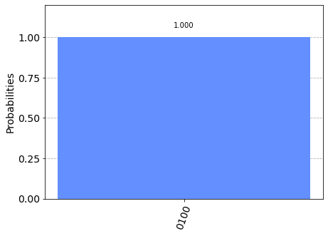

```python
def sim_and_count(circuito, backend_usado='qasm_simulator'):
    """Correr um circuito num backend ou simulador e contar os resultados obtidos"""
    backend = Aer.get_backend(backend_usado)  # para correr num computador quântico, basta trocar para um backend a sério
    results = execute(circuito, backend=backend, shots=100).result()
    counts = results.get_counts()
    return counts

counts = sim_and_count(qc)
print(counts)
plot_histogram(counts)
```

NOTA: O qiskit adota uma ordem de qubits nos circuitos tal que o qubit 0 representa o bit menos significativo e o bit $n−1$ é o mais significativo, por isso é que parece que o resultado obtido está ao contrário, mas não é verdade, é só da ordem usada. Isto faz sentido em binário, pois assim o bit $n$ representa o número $2^n$. Vamos agora tentar construir um half adder. Primeiro, temos de introduzir a porta CNOT e depois, antes de mostrarmos como fica o circuito do half adder, recorrendo a álbegra booleana, tenta deduzir como vai ficar (hint: 4 qubits, sendo 2 para adicionar, 1 para a soma e 1 para o carry)...

```python
qc = QuantumCircuit(2,2)  # o segundo parâmetro especifica quantas medições vamos fazer (o nº aparece em baixo, como '2/')
qc.x(0)
qc.cx([0],[1])  # introduzir um CNOT (controlled NOT) gate, equivalente ao XOR clássico
# No circuito, vemos que um bit é o controlador (aquele com o pontinho) e, se for =1, faz o X gate atuar no outro bit

qc.barrier()  # para se ler o circuito mais facilmente
qc.measure(0,0)  # parâmetros: (i) qubit a medir; (ii) bit clássico onde vamos guardar o valor
qc.measure(1,1)

qc.draw()
```

```
     ┌───┐      ░ ┌─┐
q_0: ┤ X ├──■───░─┤M├───
     └───┘┌─┴─┐ ░ └╥┘┌─┐
q_1: ─────┤ X ├─░──╫─┤M├
          └───┘ ░  ║ └╥┘
c: 2/══════════════╩══╩═
                   0  1
```

```
{'11': 100}
```

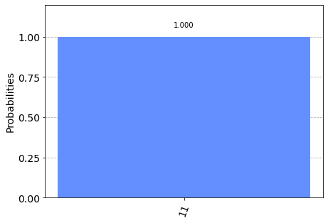

```python
counts = sim_and_count(qc)
print(counts)
plot_histogram(counts)
```

```python
qc_ha = QuantumCircuit(4,2)
# encode inputs in qubits 0 and 1
qc_ha.x(0) # For a=0, remove the this line. For a=1, leave it.
qc_ha.x(1) # For b=0, remove the this line. For b=1, leave it.
qc_ha.barrier()
# use cnots to write the XOR of the inputs on qubit 2
qc_ha.cx(0,2)
qc_ha.cx(1,2)
# use ccx to write the AND of the inputs on qubit 3 (this gate is also called the "Toffoli")
qc_ha.ccx(0,1,3)
qc_ha.barrier()
# extract outputs
qc_ha.measure(2,0) # extract XOR value
qc_ha.measure(3,1) # extract AND value

qc_ha.draw()
```

```
     ┌───┐ ░                 ░
q_0: ┤ X ├─░───■─────────■───░───────
     ├───┤ ░   │         │   ░
q_1: ┤ X ├─░───┼────■────■───░───────
     └───┘ ░ ┌─┴─┐┌─┴─┐  │   ░ ┌─┐
q_2: ──────░─┤ X ├┤ X ├──┼───░─┤M├───
           ░ └───┘└───┘┌─┴─┐ ░ └╥┘┌─┐
q_3: ──────░───────────┤ X ├─░──╫─┤M├
           ░           └───┘ ░  ║ └╥┘
c: 2/═══════════════════════════╩══╩═
                                0  1
```

```
{'10': 100}
```

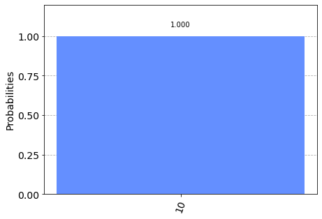

```python
# Queremos ver agora se o resultado, em binário, é o resultado dos dois bits que adicionamos
counts = sim_and_count(qc_ha)
print(counts)
plot_histogram(counts)
```